# Tetracyclines and the risk of *Clostridioides difficile* infection

Updated systematic review & Bayesian random-effects meta-analysis

Published

July 30, 2026

## Research questionDomanda di ricerca

Among patients exposed to systemic antibiotics, is exposure to a tetracycline-class antibiotic associated with a different risk of incident *C. difficile* infection (CDI) **compared with other antibiotics**? This report re-estimates the association within a Bayesian random-effects framework and quantifies the posterior probability of a protective effect. Studies whose only comparator was “no antibiotic” are analysed separately as a secondary comparison, per the PROSPERO protocol’s PECO.

Nei pazienti esposti ad antibiotici sistemici, l’esposizione a un antibiotico della classe delle tetracicline è associata a un rischio diverso di infezione incidente da *C. difficile* (ICD) **rispetto ad altri antibiotici**? Questo report ristima l’associazione con un modello bayesiano a effetti casuali e quantifica la probabilità a posteriori di un effetto protettivo. Gli studi il cui unico comparatore era “nessun antibiotico” sono analizzati separatamente come confronto secondario, secondo il PECO del protocollo PROSPERO.

## Study selection (PRISMA 2020)Selezione degli studi (PRISMA 2020)

```
flowchart TD
  A["Records identified from databases:<br/>PubMed 2016–2026 (n = 302);<br/>Scopus, Embase, Cochrane CENTRAL per protocol §15"]
  B["Records via other methods:<br/>Tariq 2018 review + backward/forward citation chasing"]
  A --> S["Records screened (title / abstract)"]
  B --> S
  S --> F["Reports assessed for eligibility (full text)"]
  F --> I["Studies included in the review (n = 35)"]
  I --> Q["Studies in the Bayesian synthesis (n = 20):<br/>Primary, vs other antibiotics (n = 11);<br/>Secondary, vs no antibiotic (n = 9)"]
```

```
flowchart TD
  A["Record individuati dai database:<br/>PubMed 2016–2026 (n = 302);<br/>Scopus, Embase, Cochrane CENTRAL secondo protocollo §15"]
  B["Record da altri metodi:<br/>revisione Tariq 2018 + citation chasing"]
  A --> S["Record sottoposti a screening (titolo / abstract)"]
  B --> S
  S --> F["Report valutati per l'eleggibilità (full text)"]
  F --> I["Studi inclusi nella revisione (n = 35)"]
  I --> Q["Studi nella sintesi bayesiana (n = 20):<br/>Primaria, vs altri antibiotici (n = 11);<br/>Secondaria, vs nessun antibiotico (n = 9)"]
```

**PRISMA 2020 flow.** Identification counts reflect the documented PubMed pilot search; the full multi-database screening tallies are completed by the student per the protocol. Of 35 included studies, 20 contribute a curated effect size to the Bayesian synthesis.

**Flusso PRISMA 2020.** I conteggi di identificazione riflettono la ricerca pilota PubMed documentata; i conteggi completi di screening multi-database vengono completati dallo studente secondo il protocollo. Dei 35 studi inclusi, 20 contribuiscono con una stima curata alla sintesi bayesiana.

## Table 1. Characteristics of included studiesTabella 1. Caratteristiche degli studi inclusi

| Study | Design | Setting | N | Agent | Comparator | Adj. | OR (95% CI) |
| --- | --- | --- | --- | --- | --- | --- | --- |
| (Watson 2018) | retrospective cohort | HA | 1,237,537 | tetracycline class | reference category | Yes | 0.39 (0.31-0.51) |
| (Baxter 2008) | matched case control | HA | 4,493 | doxycycline | reference category | Yes | 0.41 (0.27-0.63) |
| (Ström 2017) | matched case control | mixed | 584 | tetracycline | no antibiotic | No | 0.60 (0.14-2.55) |
| (Webb 2020) | retrospective cohort | HA | 506,068 | doxycycline | reference category | Yes | 0.60 (0.33-1.10) |
| (Doernberg 2012) | retrospective cohort | mixed | 2,734 | doxycycline | specific comparator | Yes | 0.73 (0.56-0.96) |
| (Tilton 2019) | matched case control | HA | 200 | doxycycline | no antibiotic | No | 0.76 (0.27-2.13) |
| (O’Leary 2023) | retrospective cohort | HA | 156,107 | doxycycline | specific comparator | Yes | 0.83 (0.70-0.99) |
| (Tartof 2015) | retrospective cohort | HA | 401,234 | tetracycline class | no antibiotic | No | 0.84 (0.63-1.10) |
| (Delaney 2007) | matched case control | CA | 13,563 | tetracycline class | no antibiotic | Yes | 0.90 (0.52-1.56) |
| (Boven 2026) | matched case control | mixed | 398,080 | tetracycline class | reference category | Yes | 0.93 (0.80-1.09) |
| (Carmichael 2023) | retrospective cohort | mixed | 50,861,011 | doxycycline | reference category | Yes | 0.94 (0.89-0.99) |
| (Kuntz 2011) | nested case control | CA | 3,344 | tetracycline class | reference category | Yes | 0.94 (0.43-2.05) |
| (Miller 2023) | matched case control | CA | 956,424 | doxycycline | reference category | Yes | 0.96 (0.90-1.03) |
| (Guh 2015) | matched case control | CA | 452 | tetracycline | no antibiotic | No | 1.00 (0.23-4.35) |
| (Dial 2008) | matched case control | CA | NR | tetracycline class | no antibiotic | Yes | 1.10 (0.12-10.20) |
| (Adams 2017) | matched case control | CA | 5,324 | tetracycline class | reference category | Yes | 1.26 (0.46-3.45) |
| (Brown 2016) | nested case control | HA | 169,453 | tetracycline | no antibiotic | Yes | 1.26 (0.86-1.85) |
| (Stojanović 2016) | matched case control | HA | 111 | tetracycline class | no antibiotic | No | 1.35 (0.22-8.47) |
| (Yu 2021) | matched case control | HA | 1,443 | tetracycline | no antibiotic | No | 2.90 (1.33-6.33) |
| (Saito 2025) | nested case control | mixed | 24,585 | tetracycline class | reference category | Yes | 2.97 (2.44-3.62) |

**Table 1.** Characteristics of the 20 studies contributing to the Bayesian synthesis (11 vs other antibiotics; 9 vs no antibiotic; ordered by odds ratio). N = analytic sample size (NR = not reported); Adj. = adjusted estimate. The OR is the single curated effect size carried into the meta-analysis; citations resolve to `references.bib`.

**Tabella 1.** Caratteristiche dei 20 studi nella sintesi bayesiana (11 vs altri antibiotici; 9 vs nessun antibiotico; ordinati per odds ratio). N = dimensione campionaria analitica (NR = non riportata); Adj. = stima aggiustata. L’OR è la singola stima d’effetto curata usata nella meta-analisi; le citazioni rimandano a `references.bib`.

## MethodsMetodi

Hierarchical random-effects model on the log-odds scale:
$$y_i \sim \text{Normal}(\theta_i, s_i^2), \qquad \theta_i \sim \text{Normal}(\mu, \tau^2).$$
Primary prior $\mu \sim \text{Normal}(0, 1^2)$; heterogeneity prior $\tau \sim \text{Half-Normal}(0, 0.5)$. Posteriors were computed exactly by numerical integration (`bayesmeta`) and independently confirmed by Hamiltonian Monte Carlo (`brms`/Stan, 4 chains). We report the pooled odds ratio (OR = exp $\mu$) with a 95% credible interval (CrI), the between-study SD $\tau$, the predictive interval for a new study, and the posterior probabilities P(OR<1) and P(OR<0.80). A pre-specified prior-sensitivity analysis used vague, sceptical and literature-informed priors.

Modello gerarchico a effetti casuali su scala log-odds:
$$y_i \sim \text{Normale}(\theta_i, s_i^2), \qquad \theta_i \sim \text{Normale}(\mu, \tau^2).$$
Prior primario $\mu \sim \text{Normale}(0, 1^2)$; prior sull’eterogeneità $\tau \sim \text{Half-Normale}(0, 0.5)$. Le distribuzioni a posteriori sono state calcolate in modo esatto per integrazione numerica (`bayesmeta`) e confermate in modo indipendente con Hamiltonian Monte Carlo (`brms`/Stan, 4 catene). Riportiamo l’odds ratio aggregato (OR = exp $\mu$) con intervallo di credibilità (ICr) al 95%, la deviazione standard tra studi $\tau$, l’intervallo predittivo per un nuovo studio e le probabilità a posteriori P(OR<1) e P(OR<0,80). Un’analisi di sensibilità sui prior pre-specificata ha usato prior vago, scettico e informato dalla letteratura.

## Primary result (11 studies)Risultato primario (11 studi)

Pooled odds ratio (tetracyclines vs other antibiotics) 0.86 (0.60–1.23)

The 95% credible interval crosses 1. The posterior probability of any protective effect is **P(OR<1) = 0.81**, and the probability of a clinically meaningful effect is **P(OR<0.80) = 0.35**. Between-study heterogeneity is substantial ($\tau$ = 0.55 (0.34–0.83)): the predictive interval for a future study spans OR 0.25–2.88.

Odds ratio aggregato (tetracicline vs altri antibiotici) 0.86 (0.60–1.23)

L’intervallo di credibilità al 95% attraversa 1. La probabilità a posteriori di un qualsiasi effetto protettivo è **P(OR<1) = 0.81**, e la probabilità di un effetto clinicamente rilevante è **P(OR<0,80) = 0.35**. L’eterogeneità tra studi è sostanziale ($\tau$ = 0.55 (0.34–0.83)): l’intervallo predittivo per uno studio futuro va da OR 0.25–2.88.

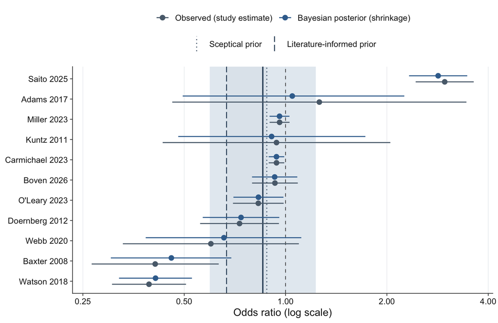

Figure 1

**Figure 1.** Study-level odds ratios (primary set, 11 studies with antibiotic comparators). Gray = observed estimates; blue = Bayesian posterior (shrinkage) estimates, pulled toward the pooled mean. The navy line and blue band show the pooled OR (primary prior) and 95% credible interval. The dotted and long-dashed vertical lines mark the pooled OR under the sceptical and literature-informed priors; the faint outer band is the prior-sensitivity range.

**Figura 1.** Odds ratio per studio (set primario, 11 studi con comparatori antibiotici). Grigio = stime osservate; blu = stime a posteriori bayesiane (shrinkage), attratte verso la media aggregata. La linea navy e la banda blu indicano l’OR aggregato (prior primario) e l’ICr al 95%. Le linee verticali punteggiata e tratteggiata indicano l’OR aggregato con i prior scettico e informato dalla letteratura; la banda esterna tenue è l’intervallo di sensibilità ai prior.

## Prior sensitivitySensibilità ai prior

The estimate is stable across data-dominated priors (primary, vague, sceptical) but shifts toward protection under the literature-informed prior centred on the earlier Tariq (2018) estimate of OR 0.62 — i.e. that conclusion is driven by prior belief, not the new data.

La stima è stabile tra i prior dominati dai dati (primario, vago, scettico) ma si sposta verso la protezione con il prior informato dalla letteratura, centrato sulla stima precedente di Tariq (2018), OR 0,62 — cioè quella conclusione è guidata dalla convinzione a priori, non dai nuovi dati.

Table 1

| Prior on μ | OR (95% CrI) | P(OR<1) | P(OR<0.80) |
| --- | --- | --- | --- |
| Primary — N(0, 1²) | 0.86 (0.60–1.23) | 0.81 | 0.35 |
| Vague — N(0, 10²) | 0.85 (0.59–1.23) | 0.82 | 0.36 |
| Sceptical — N(0, 0.35²) | 0.88 (0.64–1.21) | 0.79 | 0.27 |
| Literature — N(log 0.62, 0.10²) | 0.67 (0.56–0.80) | 1.00 | 0.98 |

Table 2

| Prior su μ | OR (ICr 95%) | P(OR<1) | P(OR<0,80) |
| --- | --- | --- | --- |
| Primario — N(0, 1²) | 0.86 (0.60–1.23) | 0.81 | 0.35 |
| Vago — N(0, 10²) | 0.85 (0.59–1.23) | 0.82 | 0.36 |
| Scettico — N(0, 0,35²) | 0.88 (0.64–1.21) | 0.79 | 0.27 |
| Letteratura — N(log 0,62, 0,10²) | 0.67 (0.56–0.80) | 1.00 | 0.98 |

## Prior-data conflictConflitto prior-dati

Because the literature-informed prior is the only assumption under which the result becomes confidently protective, we formally check whether it conflicts with the updated data. Using the Box / Marshall-Spiegelhalter measure, we compare the prior for μ — N(log 0.62, 0.10²), i.e. OR 0.62 — against the data-only estimate (vague-prior posterior: OR 0.85, log-scale mean -0.16, SD 0.19). The conflict statistic is z = -1.50 (two-sided p = 0.13), indicating **mild tension but no formal conflict**. The literature prior is more optimistic than the updated evidence, but the gap is within sampling variation. Its influence on the pooled estimate comes mainly from being far narrower (SD 0.10) than the data-only posterior (SD 0.19) rather than from statistical incompatibility with the data.

Poiché il prior informato dalla letteratura è l’unica assunzione sotto cui il risultato diventa decisamente protettivo, verifichiamo formalmente se sia in conflitto con i dati aggiornati. Con la misura di Box / Marshall-Spiegelhalter confrontiamo il prior per μ — N(log 0,62, 0,10²), cioè OR 0,62 — con la stima basata sui soli dati (posteriori con prior vago: OR 0.85, media log -0.16, SD 0.19). La statistica di conflitto è z = -1.50 (p bilaterale = 0.13), indicando **una lieve tensione ma nessun conflitto formale**. Il prior della letteratura è più ottimistico delle evidenze aggiornate, ma la differenza rientra nella variabilità campionaria. La sua influenza deriva soprattutto dall’essere molto più stretto (SD 0,10) della posteriori basata sui dati (SD 0.19), non da un’incompatibilità statistica con i dati.

## MCMC confirmation & convergenceConferma MCMC e convergenza

The two engines agree to within Monte Carlo error, confirming the exact posterior. All diagnostics indicate good convergence.

I due motori concordano entro l’errore Monte Carlo, confermando la posteriori esatta. Tutti gli indici indicano una buona convergenza.

Table 3

| Method | OR (95% CrI) | τ | P(OR<1) | P(OR<0.80) |
| --- | --- | --- | --- | --- |
| bayesmeta (exact) | 0.86 (0.60–1.23) | 0.55 | 0.81 | 0.35 |
| brms (MCMC) | 0.85 (0.60–1.23) | 0.55 | 0.81 | 0.36 |

| Parameter | R-hat | Bulk ESS | Tail ESS |
| --- | --- | --- | --- |
| μ (log-OR) | 1.000 | 2516 | 3702 |
| τ (heterogeneity SD) | 1.000 | 3217 | 5375 |

Table 4

| Metodo | OR (ICr 95%) | τ | P(OR<1) | P(OR<0,80) |
| --- | --- | --- | --- | --- |
| bayesmeta (exact) | 0.86 (0.60–1.23) | 0.55 | 0.81 | 0.35 |
| brms (MCMC) | 0.85 (0.60–1.23) | 0.55 | 0.81 | 0.36 |

| Parametro | R-hat | ESS bulk | ESS tail |
| --- | --- | --- | --- |
| μ (log-OR) | 1.000 | 2516 | 3702 |
| τ (SD eterogeneità) | 1.000 | 3217 | 5375 |

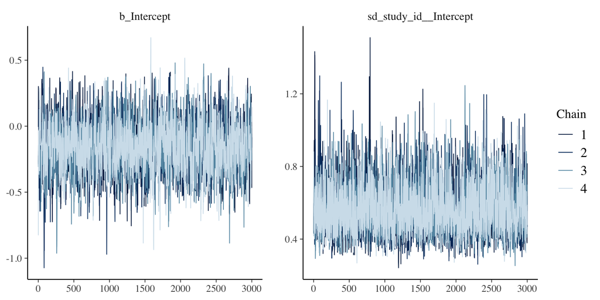

Figure 2

**Figure 2.** MCMC trace plots for the four chains (pooled log-OR and heterogeneity SD).

**Figura 2.** Trace plot MCMC per le quattro catene (log-OR aggregato e SD dell’eterogeneità).

## Small-study effectsEffetti dei piccoli studi

With k = 11 studies (meeting the pre-specified ≥10 threshold), a contour-enhanced funnel plot and Egger’s regression test assess funnel asymmetry. There is **no evidence of asymmetry** (Egger z = -0.28, p = 0.78); the studies scatter fairly symmetrically about the pooled effect. Given the observational evidence base and modest k, this is reassuring but not decisive.

Con k = 11 studi (soglia pre-specificata ≥10), un funnel plot contour-enhanced e il test di regressione di Egger valutano l’asimmetria. **Non vi è evidenza di asimmetria** (Egger z = -0.28, p = 0.78); gli studi si distribuiscono in modo abbastanza simmetrico attorno all’effetto aggregato. Data la natura osservazionale e il k contenuto, è rassicurante ma non decisivo.

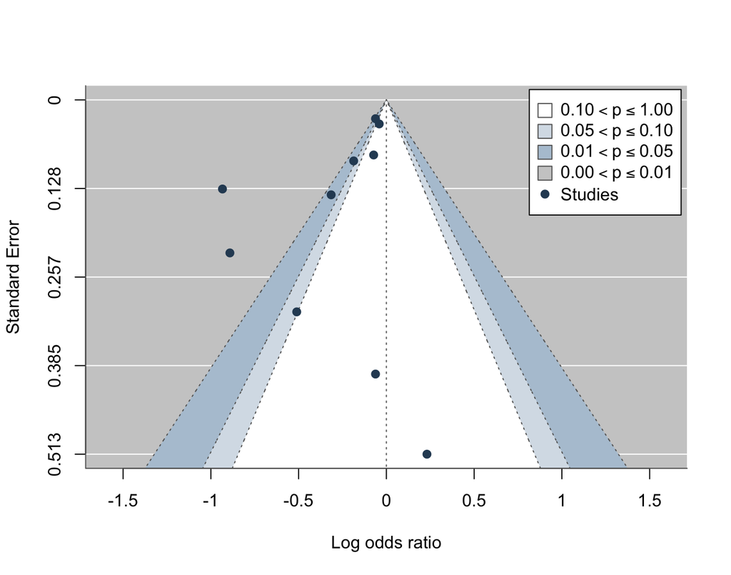

Figure 3

**Figure 3.** Contour-enhanced funnel plot; shaded bands mark the p = 0.10 / 0.05 / 0.01 regions.

**Figura 3.** Funnel plot contour-enhanced; le bande indicano le regioni p = 0,10 / 0,05 / 0,01.

## Leave-one-outAnalisi leave-one-out

No single study drives the pooled estimate: removing any one study leaves the pooled OR between 0.75 and 0.93, always below 1. The most influential study is Saito 2025 (a harmful outlier); dropping it moves the OR most toward protection, while dropping the protective Watson 2018 moves it toward the null. The qualitative conclusion is stable throughout.

Nessun singolo studio determina la stima aggregata: rimuovendo un qualsiasi studio l’OR aggregato resta tra 0.75 e 0.93, sempre inferiore a 1. Lo studio più influente è Saito 2025 (un outlier sfavorevole): la sua rimozione sposta l’OR verso la protezione, mentre rimuovere il protettivo Watson 2018 lo sposta verso l’assenza di effetto. La conclusione qualitativa resta stabile.

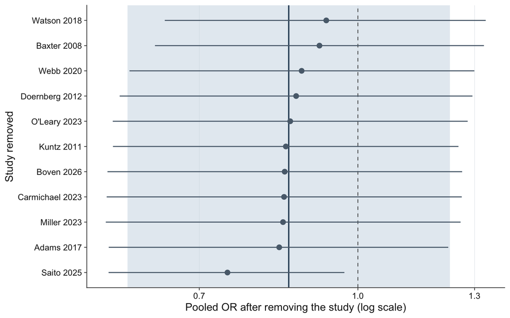

Figure 4

**Figure 4.** Leave-one-out pooled OR; the blue line and band are the full k = 11 estimate and 95% CrI.

**Figura 4.** OR aggregato leave-one-out; la linea e la banda blu sono la stima completa k = 11 e l’ICr al 95%.

## Secondary comparison: vs no antibiotic (9 studies)Confronto secondario: vs nessun antibiotico (9 studi)

Against a *no-antibiotic* comparator the association is essentially null (**OR 1.06 (0.75–1.53)**, P(OR<1) = 0.36). This is expected — almost any antibiotic raises CDI risk relative to no antibiotic — and it explains why pooling these studies into the primary set attenuated the protective signal. The two comparator questions are distinct and should not be combined.

Rispetto a un comparatore *senza antibiotico* l’associazione è sostanzialmente nulla (**OR 1.06 (0.75–1.53)**, P(OR<1) = 0.36). È un risultato atteso — quasi ogni antibiotico aumenta il rischio di ICD rispetto a nessun antibiotico — e spiega perché aggregare questi studi nel set primario attenuava il segnale protettivo. Le due domande sul comparatore sono distinte e non vanno combinate.

## SubgroupsSottogruppi

Within the primary set, the doxycycline-restricted subgroup and cohort studies lean protective, whereas case-control studies do not — a design-related divergence that warrants cautious interpretation.

All’interno del set primario, il sottogruppo limitato alla doxiciclina e gli studi di coorte tendono alla protezione, mentre gli studi caso-controllo no: una divergenza legata al disegno da interpretare con cautela.

Table 5

| Analysis | Studies (k) | OR (95% CrI) | P(OR<1) |
| --- | --- | --- | --- |
| Doxycycline only | 6 | 0.78 (0.56–1.02) | 0.97 |
| Case-control designs | 6 | 1.05 (0.60–1.82) | 0.42 |
| Cohort designs | 5 | 0.69 (0.46–1.03) | 0.97 |

Table 6

| Analisi | Studi (k) | OR (ICr 95%) | P(OR<1) |
| --- | --- | --- | --- |
| Solo doxiciclina | 6 | 0.78 (0.56–1.02) | 0.97 |
| Disegni caso-controllo | 6 | 1.05 (0.60–1.82) | 0.42 |
| Disegni di coorte | 5 | 0.69 (0.46–1.03) | 0.97 |

## Care-context meta-regressionMeta-regressione per contesto assistenziale

A pre-specified Bayesian meta-regression (exact, `bmr`) on the **primary antibiotic-comparator set (k = 11)** estimates a separate pooled OR per care context (CA 3, HA 4, mixed 4). The protective association is concentrated in **hospital-acquired (inpatient) settings** (OR 0.56 (0.33–0.94), P(OR<1) = 0.98), while community-acquired and mixed settings straddle 1. This mirrors Tariq (2018), whose setting subgroup found protection in inpatients (OR 0.55) but not mixed populations (OR 0.92). As a **sensitivity analysis on the full primary set (k = 20; CA 6, HA 9, mixed 5)**, the hospital-acquired estimate attenuates to OR 0.79 (0.54–1.17) (P(OR<1) = 0.88), because that set adds no-antibiotic-comparator studies that dilute the setting contrast. Per-group counts are small, so this is exploratory; residual heterogeneity remains (τ = 0.47).

Una meta-regressione bayesiana pre-specificata (esatta, `bmr`) sul **set primario con comparatore antibiotico (k = 11)** stima un OR aggregato per ciascun contesto (CA 3, HA 4, misto 4). L’associazione protettiva si concentra nei **contesti ospedalieri (pazienti ricoverati)** (OR 0.56 (0.33–0.94), P(OR<1) = 0.98), mentre i contesti comunitari e misti attraversano 1. Ciò rispecchia Tariq (2018), la cui analisi per contesto trovava protezione nei ricoverati (OR 0,55) ma non nelle popolazioni miste (OR 0,92). Come **analisi di sensibilità sul set primario completo (k = 20; CA 6, HA 9, misto 5)**, la stima ospedaliera si attenua a OR 0.79 (0.54–1.17) (P(OR<1) = 0.88), perché quel set aggiunge studi con comparatore “nessun antibiotico” che diluiscono il contrasto. Le numerosità per gruppo sono piccole, quindi è esplorativo; l’eterogeneità residua permane (τ = 0.47).

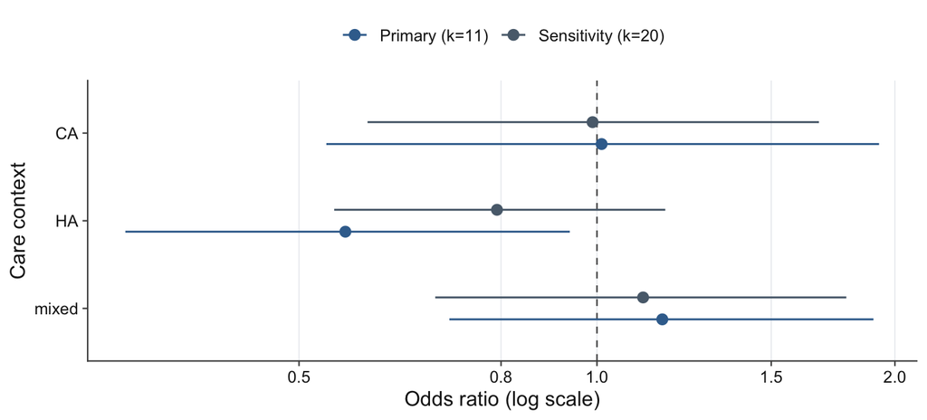

Figure 5

**Figure 5.** Care-context pooled ORs from the Bayesian meta-regression: primary antibiotic-comparator set (k = 11, blue) with full-set sensitivity (k = 20, gray).

**Figura 5.** OR aggregati per contesto dalla meta-regressione bayesiana: set primario con comparatore antibiotico (k = 11, blu) e sensibilità sul set completo (k = 20, grigio).

## Comparison with Tariq (2018)Confronto con Tariq (2018)

**Can our Bayesian approach reproduce Tariq?** Yes. Applied to Tariq’s exact six studies, a DerSimonian-Laird model reproduces their result exactly (0.62 (0.47–0.81), I² = 53%), and our Bayesian model gives a near-identical point estimate (0.63 (0.45–0.94), P(OR<1) = 0.98). The Bayesian credible interval is wider than Tariq’s confidence interval because it propagates the uncertainty in τ that is unavoidable with only six studies — the divergence is one of honest uncertainty, not of the point estimate.

**Il nostro approccio bayesiano riproduce Tariq?** Sì. Applicato ai sei studi esatti di Tariq, un modello DerSimonian-Laird ne riproduce esattamente il risultato (0.62 (0.47–0.81), I² = 53%), e il nostro modello bayesiano fornisce una stima puntuale quasi identica (0.63 (0.45–0.94), P(OR<1) = 0.98). L’intervallo di credibilità bayesiano è più ampio dell’intervallo di confidenza di Tariq perché propaga l’incertezza su τ, inevitabile con soli sei studi: la differenza riguarda l’incertezza, non la stima puntuale.

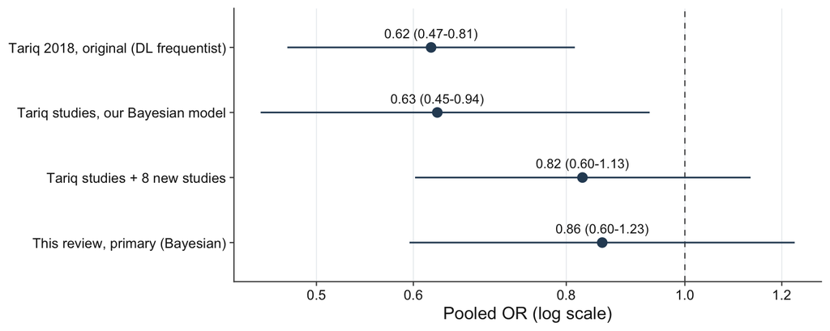

Figure 6

**Figure 6.** From Tariq to the updated review: recapitulation and stepwise decomposition of the difference.

**Figura 6.** Da Tariq alla revisione aggiornata: recupero e decomposizione passo-passo della differenza.

## InterpretationInterpretazione

Restricted to the protocol’s intended comparator (another antibiotic), the data provide **suggestive but uncertain** evidence that tetracycline exposure lowers CDI risk: the pooled OR is below 1 with a modest posterior probability of a meaningful reduction, but the credible interval still includes no effect and heterogeneity is substantial. A confidently protective conclusion emerges only under a strong literature-based prior. These findings distinguish a plausibly *lower associated risk* from established *protective therapy*.

Limitandosi al comparatore previsto dal protocollo (un altro antibiotico), i dati forniscono un’evidenza **suggestiva ma incerta** che l’esposizione alle tetracicline riduca il rischio di ICD: l’OR aggregato è inferiore a 1 con una modesta probabilità a posteriori di una riduzione rilevante, ma l’intervallo di credibilità include ancora l’assenza di effetto e l’eterogeneità è sostanziale. Una conclusione decisamente protettiva emerge solo con un forte prior basato sulla letteratura. Questi risultati distinguono un plausibile *minor rischio associato* da una *terapia protettiva* consolidata.

**Warning**

**Caveats.** All included studies are observational. Estimates convert RR/HR to OR under a rare-outcome approximation. This is evidence synthesis for research and education, not treatment guidance for individual patients.

**Avvertenze.** Tutti gli studi inclusi sono osservazionali. Le stime convertono RR/HR in OR con un’approssimazione per esiti rari. Si tratta di una sintesi delle evidenze a scopo di ricerca ed educativo, non di una guida terapeutica per il singolo paziente.

## ReferencesBibliografia

Bibliographic entries for the studies in the synthesis are cited in Table 1 and listed below. Author and year are taken from the extraction; titles, journals and DOIs in `references.bib` are a scaffold to be verified/completed by the author (Tariq 2018 and a few studies whose DOIs came from the source files are complete).

Le voci bibliografiche degli studi nella sintesi sono citate nella Tabella 1 ed elencate qui sotto. Autore e anno provengono dall’estrazione; titoli, riviste e DOI in `references.bib` sono uno scheletro da verificare/completare (Tariq 2018 e alcuni studi con DOI dai file sorgente sono completi).

Adams, Daniel J. 2017. *[Tetracyclines and Community-Associated C. Difficile Infection — Title to Verify]*.

Baxter, R. 2008. *[Doxycycline Exposure and C. Difficile Infection — Title to Verify]*.

Boven, A. 2026. *[Tetracyclines and Community-Associated C. Difficile Infection — Title to Verify]*.

Brown, Kevin A. 2016. *[Tetracyclines and C. Difficile Infection — Title to Verify]*.

Carmichael, H. 2023. *[Doxycycline and C. Difficile Infection — Title to Verify]*.

Delaney, J. A. 2007. *[Tetracyclines and C. Difficile Infection — Title to Verify]*.

Dial, Sandra. 2008. “[Tetracyclines and Community-Associated C. Difficile Infection — Title to Verify].” *CMAJ*, ahead of print. https://doi.org/10.1503/cmaj.071812.

Doernberg, Sarah B. 2012. “[Doxycycline and C. Difficile Infection in Ceftriaxone Recipients — Title to Verify].” *Clinical Infectious Diseases*, ahead of print. https://doi.org/10.1093/cid/cis457.

Guh, Alice Y. 2015. *[Tetracyclines and Community-Associated C. Difficile Infection — Title to Verify]*.

Kuntz, Jennifer L. 2011. “[Tetracyclines and Community-Associated C. Difficile Infection — Title to Verify].” *BMC Infectious Diseases*, ahead of print. https://doi.org/10.1186/1471-2334-11-194.

Miller, A. C. 2023. *[Doxycycline/Minocycline and C. Difficile Infection — Title to Verify]*.

O’Leary, Ashley L. 2023. *[Doxycycline Versus Azithromycin and C. Difficile Infection — Title to Verify]*.

Saito, H. 2025. *[Tetracyclines and C. Difficile Infection — Title to Verify]*.

Stojanović, Predrag. 2016. *[Tetracyclines and C. Difficile Infection — Title to Verify]*.

Ström, J. 2017. *[Tetracyclines and C. Difficile Infection — Title to Verify]*.

Tartof, S. Y. 2015. *[Doxycycline and C. Difficile Infection — Title to Verify]*.

Tilton, C. S. 2019. *[Doxycycline and C. Difficile Infection — Title to Verify]*.

Watson, T. 2018. *[Tetracyclines and C. Difficile Infection — Title to Verify]*.

Webb, Brandon J. 2020. *[Doxycycline and C. Difficile Infection — Title to Verify]*.

Yu, J. 2021. *[Tetracyclines and C. Difficile Infection — Title to Verify]*.

Reproducible source: `report.qmd`. Bayesian normal-normal hierarchical model (`bayesmeta`, exact numerical posterior), confirmed by `brms`/Stan MCMC. Re-render with `quarto render report.qmd`.

Sorgente riproducibile: `report.qmd`. Modello gerarchico normale-normale bayesiano (`bayesmeta`, posteriori numerica esatta), confermato con MCMC `brms`/Stan. Ri-generare con `quarto render report.qmd`.